# Risk Factor Analysis

## Outcome Variable

**Outcome Variable:** ever_co

## Predictor Variables

**Intervention Variable:** mhtcm

**Adjustment Set:**

- arm
- W_mage
- meducyrs
- feducyrs
- delta_W_mage
- delta_meducyrs
- delta_feducyrs

## Stratifying Variables

The analysis was stratified on these variable(s):

- agecat
- studyid
- country

## Data Summary

| agecat | studyid | country | mhtcm | ever_co | n_cell | n |
| --- | --- | --- | --- | --- | --- | --- |
| 0-24 months | ki0047075b-MAL-ED | BANGLADESH | >=155 cm | 0 | 23 | 254 |
| 0-24 months | ki0047075b-MAL-ED | BANGLADESH | >=155 cm | 1 | 2 | 254 |
| 0-24 months | ki0047075b-MAL-ED | BANGLADESH | <151 cm | 0 | 131 | 254 |
| 0-24 months | ki0047075b-MAL-ED | BANGLADESH | <151 cm | 1 | 32 | 254 |
| 0-24 months | ki0047075b-MAL-ED | BANGLADESH | [151-155) cm | 0 | 61 | 254 |
| 0-24 months | ki0047075b-MAL-ED | BANGLADESH | [151-155) cm | 1 | 5 | 254 |
| 0-24 months | ki0047075b-MAL-ED | BRAZIL | >=155 cm | 0 | 129 | 222 |
| 0-24 months | ki0047075b-MAL-ED | BRAZIL | >=155 cm | 1 | 1 | 222 |
| 0-24 months | ki0047075b-MAL-ED | BRAZIL | <151 cm | 0 | 52 | 222 |
| 0-24 months | ki0047075b-MAL-ED | BRAZIL | <151 cm | 1 | 1 | 222 |
| 0-24 months | ki0047075b-MAL-ED | BRAZIL | [151-155) cm | 0 | 39 | 222 |
| 0-24 months | ki0047075b-MAL-ED | BRAZIL | [151-155) cm | 1 | 0 | 222 |
| 0-24 months | ki0047075b-MAL-ED | INDIA | >=155 cm | 0 | 49 | 242 |
| 0-24 months | ki0047075b-MAL-ED | INDIA | >=155 cm | 1 | 6 | 242 |
| 0-24 months | ki0047075b-MAL-ED | INDIA | <151 cm | 0 | 82 | 242 |
| 0-24 months | ki0047075b-MAL-ED | INDIA | <151 cm | 1 | 33 | 242 |
| 0-24 months | ki0047075b-MAL-ED | INDIA | [151-155) cm | 0 | 58 | 242 |
| 0-24 months | ki0047075b-MAL-ED | INDIA | [151-155) cm | 1 | 14 | 242 |
| 0-24 months | ki0047075b-MAL-ED | NEPAL | >=155 cm | 0 | 41 | 238 |
| 0-24 months | ki0047075b-MAL-ED | NEPAL | >=155 cm | 1 | 0 | 238 |
| 0-24 months | ki0047075b-MAL-ED | NEPAL | <151 cm | 0 | 114 | 238 |
| 0-24 months | ki0047075b-MAL-ED | NEPAL | <151 cm | 1 | 19 | 238 |
| 0-24 months | ki0047075b-MAL-ED | NEPAL | [151-155) cm | 0 | 62 | 238 |
| 0-24 months | ki0047075b-MAL-ED | NEPAL | [151-155) cm | 1 | 2 | 238 |
| 0-24 months | ki0047075b-MAL-ED | PERU | >=155 cm | 0 | 60 | 290 |
| 0-24 months | ki0047075b-MAL-ED | PERU | >=155 cm | 1 | 0 | 290 |
| 0-24 months | ki0047075b-MAL-ED | PERU | <151 cm | 0 | 161 | 290 |
| 0-24 months | ki0047075b-MAL-ED | PERU | <151 cm | 1 | 8 | 290 |
| 0-24 months | ki0047075b-MAL-ED | PERU | [151-155) cm | 0 | 57 | 290 |
| 0-24 months | ki0047075b-MAL-ED | PERU | [151-155) cm | 1 | 4 | 290 |

[output cut: 378 more lines]

The following strata were considered:

- agecat: 0-24 months, studyid: ki0047075b-MAL-ED, country: BANGLADESH
- agecat: 0-24 months, studyid: ki0047075b-MAL-ED, country: BRAZIL
- agecat: 0-24 months, studyid: ki0047075b-MAL-ED, country: INDIA
- agecat: 0-24 months, studyid: ki0047075b-MAL-ED, country: NEPAL
- agecat: 0-24 months, studyid: ki0047075b-MAL-ED, country: PERU
- agecat: 0-24 months, studyid: ki0047075b-MAL-ED, country: SOUTH AFRICA
- agecat: 0-24 months, studyid: ki0047075b-MAL-ED, country: TANZANIA, UNITED REPUBLIC OF
- agecat: 0-24 months, studyid: ki1000304b-SAS-CompFeed, country: INDIA
- agecat: 0-24 months, studyid: ki1000304b-SAS-FoodSuppl, country: INDIA
- agecat: 0-24 months, studyid: ki1017093-NIH-Birth, country: BANGLADESH
- agecat: 0-24 months, studyid: ki1017093b-PROVIDE, country: BANGLADESH
- agecat: 0-24 months, studyid: ki1017093c-NIH-Crypto, country: BANGLADESH
- agecat: 0-24 months, studyid: ki1066203-TanzaniaChild2, country: TANZANIA, UNITED REPUBLIC OF
- agecat: 0-24 months, studyid: ki1101329-Keneba, country: GAMBIA
- agecat: 0-24 months, studyid: ki1112895-Guatemala BSC, country: GUATEMALA
- agecat: 0-24 months, studyid: ki1112895-iLiNS-Zinc, country: BURKINA FASO
- agecat: 0-24 months, studyid: ki1119695-PROBIT, country: BELARUS
- agecat: 0-24 months, studyid: ki1126311-ZVITAMBO, country: ZIMBABWE
- agecat: 0-24 months, studyid: ki1135781-COHORTS, country: GUATEMALA
- agecat: 0-24 months, studyid: ki1135781-COHORTS, country: INDIA
- agecat: 0-24 months, studyid: ki1135781-COHORTS, country: PHILIPPINES
- agecat: 0-24 months, studyid: ki1148112-LCNI-5, country: MALAWI
- agecat: 0-24 months, studyid: kiGH5241-JiVitA-3, country: BANGLADESH
- agecat: 0-6 months, studyid: ki0047075b-MAL-ED, country: BANGLADESH
- agecat: 0-6 months, studyid: ki0047075b-MAL-ED, country: BRAZIL
- agecat: 0-6 months, studyid: ki0047075b-MAL-ED, country: INDIA
- agecat: 0-6 months, studyid: ki0047075b-MAL-ED, country: NEPAL
- agecat: 0-6 months, studyid: ki0047075b-MAL-ED, country: PERU
- agecat: 0-6 months, studyid: ki0047075b-MAL-ED, country: SOUTH AFRICA
- agecat: 0-6 months, studyid: ki0047075b-MAL-ED, country: TANZANIA, UNITED REPUBLIC OF
- agecat: 0-6 months, studyid: ki1000304b-SAS-CompFeed, country: INDIA
- agecat: 0-6 months, studyid: ki1000304b-SAS-FoodSuppl, country: INDIA
- agecat: 0-6 months, studyid: ki1017093-NIH-Birth, country: BANGLADESH
- agecat: 0-6 months, studyid: ki1017093b-PROVIDE, country: BANGLADESH
- agecat: 0-6 months, studyid: ki1017093c-NIH-Crypto, country: BANGLADESH
- agecat: 0-6 months, studyid: ki1066203-TanzaniaChild2, country: TANZANIA, UNITED REPUBLIC OF
- agecat: 0-6 months, studyid: ki1101329-Keneba, country: GAMBIA
- agecat: 0-6 months, studyid: ki1112895-Guatemala BSC, country: GUATEMALA
- agecat: 0-6 months, studyid: ki1119695-PROBIT, country: BELARUS
- agecat: 0-6 months, studyid: ki1126311-ZVITAMBO, country: ZIMBABWE
- agecat: 0-6 months, studyid: ki1135781-COHORTS, country: GUATEMALA
- agecat: 0-6 months, studyid: ki1135781-COHORTS, country: INDIA
- agecat: 0-6 months, studyid: ki1135781-COHORTS, country: PHILIPPINES
- agecat: 0-6 months, studyid: ki1148112-LCNI-5, country: MALAWI
- agecat: 0-6 months, studyid: kiGH5241-JiVitA-3, country: BANGLADESH
- agecat: 6-24 months, studyid: ki0047075b-MAL-ED, country: BANGLADESH
- agecat: 6-24 months, studyid: ki0047075b-MAL-ED, country: BRAZIL
- agecat: 6-24 months, studyid: ki0047075b-MAL-ED, country: INDIA
- agecat: 6-24 months, studyid: ki0047075b-MAL-ED, country: NEPAL
- agecat: 6-24 months, studyid: ki0047075b-MAL-ED, country: PERU
- agecat: 6-24 months, studyid: ki0047075b-MAL-ED, country: SOUTH AFRICA
- agecat: 6-24 months, studyid: ki0047075b-MAL-ED, country: TANZANIA, UNITED REPUBLIC OF
- agecat: 6-24 months, studyid: ki1000304b-SAS-CompFeed, country: INDIA
- agecat: 6-24 months, studyid: ki1000304b-SAS-FoodSuppl, country: INDIA
- agecat: 6-24 months, studyid: ki1017093-NIH-Birth, country: BANGLADESH
- agecat: 6-24 months, studyid: ki1017093b-PROVIDE, country: BANGLADESH
- agecat: 6-24 months, studyid: ki1017093c-NIH-Crypto, country: BANGLADESH
- agecat: 6-24 months, studyid: ki1066203-TanzaniaChild2, country: TANZANIA, UNITED REPUBLIC OF
- agecat: 6-24 months, studyid: ki1101329-Keneba, country: GAMBIA
- agecat: 6-24 months, studyid: ki1112895-Guatemala BSC, country: GUATEMALA
- agecat: 6-24 months, studyid: ki1112895-iLiNS-Zinc, country: BURKINA FASO
- agecat: 6-24 months, studyid: ki1119695-PROBIT, country: BELARUS
- agecat: 6-24 months, studyid: ki1126311-ZVITAMBO, country: ZIMBABWE
- agecat: 6-24 months, studyid: ki1135781-COHORTS, country: GUATEMALA
- agecat: 6-24 months, studyid: ki1135781-COHORTS, country: INDIA
- agecat: 6-24 months, studyid: ki1135781-COHORTS, country: PHILIPPINES
- agecat: 6-24 months, studyid: ki1148112-LCNI-5, country: MALAWI
- agecat: 6-24 months, studyid: kiGH5241-JiVitA-3, country: BANGLADESH

### Dropped Strata

Some strata were dropped due to rare outcomes:

- agecat: 0-24 months, studyid: ki0047075b-MAL-ED, country: BANGLADESH
- agecat: 0-24 months, studyid: ki0047075b-MAL-ED, country: BRAZIL
- agecat: 0-24 months, studyid: ki0047075b-MAL-ED, country: NEPAL
- agecat: 0-24 months, studyid: ki0047075b-MAL-ED, country: PERU
- agecat: 0-24 months, studyid: ki0047075b-MAL-ED, country: SOUTH AFRICA
- agecat: 0-24 months, studyid: ki1112895-Guatemala BSC, country: GUATEMALA
- agecat: 0-24 months, studyid: ki1119695-PROBIT, country: BELARUS
- agecat: 0-6 months, studyid: ki0047075b-MAL-ED, country: BANGLADESH
- agecat: 0-6 months, studyid: ki0047075b-MAL-ED, country: BRAZIL
- agecat: 0-6 months, studyid: ki0047075b-MAL-ED, country: INDIA
- agecat: 0-6 months, studyid: ki0047075b-MAL-ED, country: NEPAL
- agecat: 0-6 months, studyid: ki0047075b-MAL-ED, country: PERU
- agecat: 0-6 months, studyid: ki0047075b-MAL-ED, country: SOUTH AFRICA
- agecat: 0-6 months, studyid: ki0047075b-MAL-ED, country: TANZANIA, UNITED REPUBLIC OF
- agecat: 0-6 months, studyid: ki1000304b-SAS-FoodSuppl, country: INDIA
- agecat: 0-6 months, studyid: ki1017093c-NIH-Crypto, country: BANGLADESH
- agecat: 0-6 months, studyid: ki1066203-TanzaniaChild2, country: TANZANIA, UNITED REPUBLIC OF
- agecat: 0-6 months, studyid: ki1112895-Guatemala BSC, country: GUATEMALA
- agecat: 0-6 months, studyid: ki1119695-PROBIT, country: BELARUS
- agecat: 0-6 months, studyid: ki1135781-COHORTS, country: GUATEMALA
- agecat: 0-6 months, studyid: ki1148112-LCNI-5, country: MALAWI
- agecat: 6-24 months, studyid: ki0047075b-MAL-ED, country: BANGLADESH
- agecat: 6-24 months, studyid: ki0047075b-MAL-ED, country: BRAZIL
- agecat: 6-24 months, studyid: ki0047075b-MAL-ED, country: NEPAL
- agecat: 6-24 months, studyid: ki0047075b-MAL-ED, country: PERU
- agecat: 6-24 months, studyid: ki0047075b-MAL-ED, country: SOUTH AFRICA
- agecat: 6-24 months, studyid: ki1112895-Guatemala BSC, country: GUATEMALA
- agecat: 6-24 months, studyid: ki1119695-PROBIT, country: BELARUS

## Methods Detail

We’re interested in the causal parameters $E[Y_a]$ for all values of $a \in \mathcal{A}$. These parameters represent the mean outcome if, possibly contrary to fact, we intervened to set all units to have $A=a$. Under the randomization and positivity assumptions, these are identified by the statistical parameters $\psi_a=E_W[E_{Y|A,W}(Y|A=a,W)]$. In addition, we’re interested in the mean of $Y$, $E[Y]$ under no intervention (the observed mean). We will estimate these parameters by using SuperLearner to fit the relevant likelihood factors – $E_{Y|A,W}(Y|A=a,W)$ and $p(A=a|W)$, and then updating our likelihood fit using a joint TMLE.

For unadjusted analyses ($W=\{\}$), initial likelihoods were estimated using Lrnr_glm to estimate the simple $E(Y|A)$ and Lrnr_mean to estimate $p(A)$. For adjusted analyses, a small library containing Lrnr_glmnet, Lrnr_xgboost, and Lrnr_mean was used.

Having estimated these parameters, we will then use the delta method to estimate relative risks and attributable risks relative to a prespecified baseline level of $A$.

# Results Detail

## Results Plots

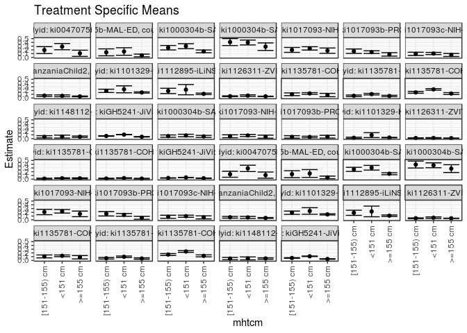

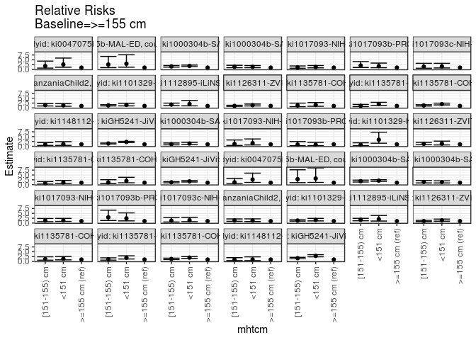

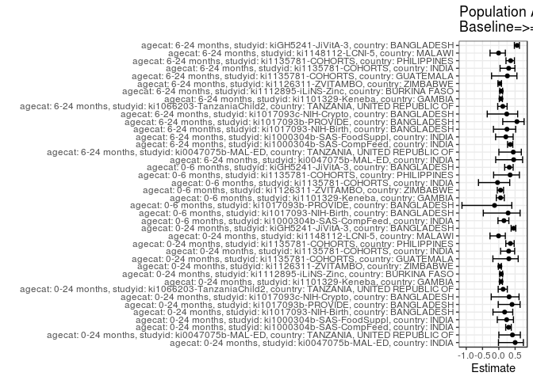

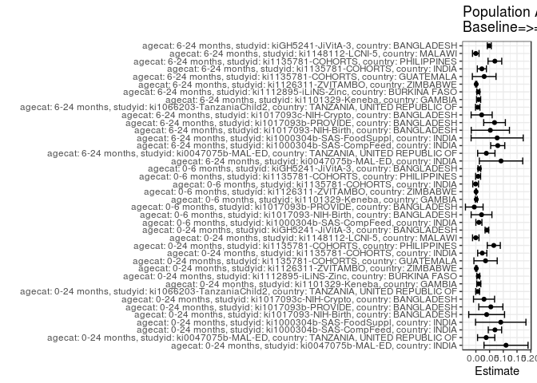

## Results Table

### Parameter: TSM

| agecat | studyid | country | intervention_level | baseline_level | estimate | ci_lower | ci_upper |
| --- | --- | --- | --- | --- | --- | --- | --- |
| 0-24 months | ki0047075b-MAL-ED | INDIA | >=155 cm | NA | 0.1090909 | 0.0265295 | 0.1916523 |
| 0-24 months | ki0047075b-MAL-ED | INDIA | <151 cm | NA | 0.2869565 | 0.2041119 | 0.3698012 |
| 0-24 months | ki0047075b-MAL-ED | INDIA | [151-155) cm | NA | 0.1944444 | 0.1028379 | 0.2860510 |
| 0-24 months | ki0047075b-MAL-ED | TANZANIA, UNITED REPUBLIC OF | >=155 cm | NA | 0.0522876 | 0.0169457 | 0.0876295 |
| 0-24 months | ki0047075b-MAL-ED | TANZANIA, UNITED REPUBLIC OF | <151 cm | NA | 0.1568627 | 0.0568577 | 0.2568678 |
| 0-24 months | ki0047075b-MAL-ED | TANZANIA, UNITED REPUBLIC OF | [151-155) cm | NA | 0.1346154 | 0.0416656 | 0.2275651 |
| 0-24 months | ki1000304b-SAS-CompFeed | INDIA | >=155 cm | NA | 0.1606722 | 0.1248126 | 0.1965318 |
| 0-24 months | ki1000304b-SAS-CompFeed | INDIA | <151 cm | NA | 0.2993897 | 0.2338113 | 0.3649682 |
| 0-24 months | ki1000304b-SAS-CompFeed | INDIA | [151-155) cm | NA | 0.2584398 | 0.1992115 | 0.3176682 |
| 0-24 months | ki1000304b-SAS-FoodSuppl | INDIA | >=155 cm | NA | 0.2858254 | 0.1855911 | 0.3860597 |
| 0-24 months | ki1000304b-SAS-FoodSuppl | INDIA | <151 cm | NA | 0.3970171 | 0.3321728 | 0.4618614 |
| 0-24 months | ki1000304b-SAS-FoodSuppl | INDIA | [151-155) cm | NA | 0.4088523 | 0.3164639 | 0.5012408 |
| 0-24 months | ki1017093-NIH-Birth | BANGLADESH | >=155 cm | NA | 0.1803074 | 0.1093188 | 0.2512960 |
| 0-24 months | ki1017093-NIH-Birth | BANGLADESH | <151 cm | NA | 0.2402871 | 0.1959147 | 0.2846594 |
| 0-24 months | ki1017093-NIH-Birth | BANGLADESH | [151-155) cm | NA | 0.1994280 | 0.1339514 | 0.2649047 |
| 0-24 months | ki1017093b-PROVIDE | BANGLADESH | >=155 cm | NA | 0.0799598 | 0.0338707 | 0.1260489 |
| 0-24 months | ki1017093b-PROVIDE | BANGLADESH | <151 cm | NA | 0.1412900 | 0.1058226 | 0.1767573 |
| 0-24 months | ki1017093b-PROVIDE | BANGLADESH | [151-155) cm | NA | 0.1657372 | 0.1068272 | 0.2246471 |
| 0-24 months | ki1017093c-NIH-Crypto | BANGLADESH | >=155 cm | NA | 0.0642857 | 0.0236320 | 0.1049395 |
| 0-24 months | ki1017093c-NIH-Crypto | BANGLADESH | <151 cm | NA | 0.1034483 | 0.0748104 | 0.1320861 |
| 0-24 months | ki1017093c-NIH-Crypto | BANGLADESH | [151-155) cm | NA | 0.0944444 | 0.0516935 | 0.1371954 |
| 0-24 months | ki1066203-TanzaniaChild2 | TANZANIA, UNITED REPUBLIC OF | >=155 cm | NA | 0.0426739 | 0.0323865 | 0.0529614 |
| 0-24 months | ki1066203-TanzaniaChild2 | TANZANIA, UNITED REPUBLIC OF | <151 cm | NA | 0.0577668 | 0.0338987 | 0.0816350 |
| 0-24 months | ki1066203-TanzaniaChild2 | TANZANIA, UNITED REPUBLIC OF | [151-155) cm | NA | 0.0632114 | 0.0422097 | 0.0842131 |
| 0-24 months | ki1101329-Keneba | GAMBIA | >=155 cm | NA | 0.1470590 | 0.1316253 | 0.1624928 |
| 0-24 months | ki1101329-Keneba | GAMBIA | <151 cm | NA | 0.2316876 | 0.1390422 | 0.3243329 |
| 0-24 months | ki1101329-Keneba | GAMBIA | [151-155) cm | NA | 0.1909799 | 0.1475783 | 0.2343815 |
| 0-24 months | ki1112895-iLiNS-Zinc | BURKINA FASO | >=155 cm | NA | 0.1104164 | 0.0907972 | 0.1300356 |
| 0-24 months | ki1112895-iLiNS-Zinc | BURKINA FASO | <151 cm | NA | 0.2223931 | 0.0851905 | 0.3595958 |
| 0-24 months | ki1112895-iLiNS-Zinc | BURKINA FASO | [151-155) cm | NA | 0.1888712 | 0.1180770 | 0.2596653 |

[output cut: 90 more lines]

### Parameter: E(Y)

| agecat | studyid | country | intervention_level | baseline_level | estimate | ci_lower | ci_upper |
| --- | --- | --- | --- | --- | --- | --- | --- |
| 0-24 months | ki0047075b-MAL-ED | INDIA | NA | NA | 0.2190083 | 0.1667935 | 0.2712230 |
| 0-24 months | ki0047075b-MAL-ED | TANZANIA, UNITED REPUBLIC OF | NA | NA | 0.0898438 | 0.0547459 | 0.1249416 |
| 0-24 months | ki1000304b-SAS-CompFeed | INDIA | NA | NA | 0.2302158 | 0.1856981 | 0.2747335 |
| 0-24 months | ki1000304b-SAS-FoodSuppl | INDIA | NA | NA | 0.3765281 | 0.3295143 | 0.4235419 |
| 0-24 months | ki1017093-NIH-Birth | BANGLADESH | NA | NA | 0.2195513 | 0.1870467 | 0.2520558 |
| 0-24 months | ki1017093b-PROVIDE | BANGLADESH | NA | NA | 0.1345291 | 0.1086533 | 0.1604050 |
| 0-24 months | ki1017093c-NIH-Crypto | BANGLADESH | NA | NA | 0.0940397 | 0.0732057 | 0.1148737 |
| 0-24 months | ki1066203-TanzaniaChild2 | TANZANIA, UNITED REPUBLIC OF | NA | NA | 0.0491734 | 0.0404458 | 0.0579009 |
| 0-24 months | ki1101329-Keneba | GAMBIA | NA | NA | 0.1577430 | 0.1432416 | 0.1722444 |
| 0-24 months | ki1112895-iLiNS-Zinc | BURKINA FASO | NA | NA | 0.1192949 | 0.0996089 | 0.1389809 |
| 0-24 months | ki1126311-ZVITAMBO | ZIMBABWE | NA | NA | 0.0462963 | 0.0421418 | 0.0504508 |
| 0-24 months | ki1135781-COHORTS | GUATEMALA | NA | NA | 0.1145098 | 0.0970244 | 0.1319952 |
| 0-24 months | ki1135781-COHORTS | INDIA | NA | NA | 0.0766404 | 0.0646915 | 0.0885893 |
| 0-24 months | ki1135781-COHORTS | PHILIPPINES | NA | NA | 0.1839080 | 0.1701456 | 0.1976705 |
| 0-24 months | ki1148112-LCNI-5 | MALAWI | NA | NA | 0.0501792 | 0.0353804 | 0.0649781 |
| 0-24 months | kiGH5241-JiVitA-3 | BANGLADESH | NA | NA | 0.0886336 | 0.0847410 | 0.0925262 |
| 0-6 months | ki1000304b-SAS-CompFeed | INDIA | NA | NA | 0.0694645 | 0.0441638 | 0.0947653 |
| 0-6 months | ki1017093-NIH-Birth | BANGLADESH | NA | NA | 0.0723473 | 0.0519719 | 0.0927227 |
| 0-6 months | ki1017093b-PROVIDE | BANGLADESH | NA | NA | 0.0448430 | 0.0291486 | 0.0605375 |
| 0-6 months | ki1101329-Keneba | GAMBIA | NA | NA | 0.0286385 | 0.0215537 | 0.0357233 |
| 0-6 months | ki1126311-ZVITAMBO | ZIMBABWE | NA | NA | 0.0123633 | 0.0101740 | 0.0145527 |
| 0-6 months | ki1135781-COHORTS | INDIA | NA | NA | 0.0225443 | 0.0158017 | 0.0292868 |
| 0-6 months | ki1135781-COHORTS | PHILIPPINES | NA | NA | 0.0236531 | 0.0182537 | 0.0290525 |
| 0-6 months | kiGH5241-JiVitA-3 | BANGLADESH | NA | NA | 0.0393258 | 0.0368315 | 0.0418201 |
| 6-24 months | ki0047075b-MAL-ED | INDIA | NA | NA | 0.2008547 | 0.1494120 | 0.2522974 |
| 6-24 months | ki0047075b-MAL-ED | TANZANIA, UNITED REPUBLIC OF | NA | NA | 0.0857143 | 0.0505889 | 0.1208396 |
| 6-24 months | ki1000304b-SAS-CompFeed | INDIA | NA | NA | 0.2255286 | 0.1871466 | 0.2639106 |
| 6-24 months | ki1000304b-SAS-FoodSuppl | INDIA | NA | NA | 0.3600000 | 0.3129020 | 0.4070980 |
| 6-24 months | ki1017093-NIH-Birth | BANGLADESH | NA | NA | 0.2103321 | 0.1759902 | 0.2446740 |
| 6-24 months | ki1017093b-PROVIDE | BANGLADESH | NA | NA | 0.1223491 | 0.0963874 | 0.1483108 |
| 6-24 months | ki1017093c-NIH-Crypto | BANGLADESH | NA | NA | 0.0863014 | 0.0659171 | 0.1066856 |
| 6-24 months | ki1066203-TanzaniaChild2 | TANZANIA, UNITED REPUBLIC OF | NA | NA | 0.0554435 | 0.0453713 | 0.0655158 |
| 6-24 months | ki1101329-Keneba | GAMBIA | NA | NA | 0.1544750 | 0.1397785 | 0.1691716 |
| 6-24 months | ki1112895-iLiNS-Zinc | BURKINA FASO | NA | NA | 0.1192949 | 0.0996089 | 0.1389809 |
| 6-24 months | ki1126311-ZVITAMBO | ZIMBABWE | NA | NA | 0.0411182 | 0.0369177 | 0.0453187 |
| 6-24 months | ki1135781-COHORTS | GUATEMALA | NA | NA | 0.1152513 | 0.0968196 | 0.1336830 |
| 6-24 months | ki1135781-COHORTS | INDIA | NA | NA | 0.0721649 | 0.0603481 | 0.0839818 |
| 6-24 months | ki1135781-COHORTS | PHILIPPINES | NA | NA | 0.1908832 | 0.1763448 | 0.2054216 |
| 6-24 months | ki1148112-LCNI-5 | MALAWI | NA | NA | 0.0510328 | 0.0359888 | 0.0660768 |
| 6-24 months | kiGH5241-JiVitA-3 | BANGLADESH | NA | NA | 0.0868884 | 0.0822172 | 0.0915596 |

### Parameter: RR

| agecat | studyid | country | intervention_level | baseline_level | estimate | ci_lower | ci_upper |
| --- | --- | --- | --- | --- | --- | --- | --- |
| 0-24 months | ki0047075b-MAL-ED | INDIA | >=155 cm | >=155 cm | 1.0000000 | 1.0000000 | 1.000000 |
| 0-24 months | ki0047075b-MAL-ED | INDIA | <151 cm | >=155 cm | 2.6304348 | 1.1701604 | 5.913025 |
| 0-24 months | ki0047075b-MAL-ED | INDIA | [151-155) cm | >=155 cm | 1.7824074 | 0.7308807 | 4.346778 |
| 0-24 months | ki0047075b-MAL-ED | TANZANIA, UNITED REPUBLIC OF | >=155 cm | >=155 cm | 1.0000000 | 1.0000000 | 1.000000 |
| 0-24 months | ki0047075b-MAL-ED | TANZANIA, UNITED REPUBLIC OF | <151 cm | >=155 cm | 3.0000000 | 1.1846760 | 7.597014 |
| 0-24 months | ki0047075b-MAL-ED | TANZANIA, UNITED REPUBLIC OF | [151-155) cm | >=155 cm | 2.5745192 | 0.9796292 | 6.765978 |
| 0-24 months | ki1000304b-SAS-CompFeed | INDIA | >=155 cm | >=155 cm | 1.0000000 | 1.0000000 | 1.000000 |
| 0-24 months | ki1000304b-SAS-CompFeed | INDIA | <151 cm | >=155 cm | 1.8633573 | 1.5279110 | 2.272449 |
| 0-24 months | ki1000304b-SAS-CompFeed | INDIA | [151-155) cm | >=155 cm | 1.6084913 | 1.2428648 | 2.081678 |
| 0-24 months | ki1000304b-SAS-FoodSuppl | INDIA | >=155 cm | >=155 cm | 1.0000000 | 1.0000000 | 1.000000 |
| 0-24 months | ki1000304b-SAS-FoodSuppl | INDIA | <151 cm | >=155 cm | 1.3890197 | 0.9434930 | 2.044929 |
| 0-24 months | ki1000304b-SAS-FoodSuppl | INDIA | [151-155) cm | >=155 cm | 1.4304269 | 0.9422593 | 2.171505 |
| 0-24 months | ki1017093-NIH-Birth | BANGLADESH | >=155 cm | >=155 cm | 1.0000000 | 1.0000000 | 1.000000 |
| 0-24 months | ki1017093-NIH-Birth | BANGLADESH | <151 cm | >=155 cm | 1.3326521 | 0.8623417 | 2.059464 |
| 0-24 months | ki1017093-NIH-Birth | BANGLADESH | [151-155) cm | >=155 cm | 1.1060444 | 0.6622846 | 1.847143 |
| 0-24 months | ki1017093b-PROVIDE | BANGLADESH | >=155 cm | >=155 cm | 1.0000000 | 1.0000000 | 1.000000 |
| 0-24 months | ki1017093b-PROVIDE | BANGLADESH | <151 cm | >=155 cm | 1.7670125 | 0.9422663 | 3.313642 |
| 0-24 months | ki1017093b-PROVIDE | BANGLADESH | [151-155) cm | >=155 cm | 2.0727563 | 1.0530121 | 4.080028 |
| 0-24 months | ki1017093c-NIH-Crypto | BANGLADESH | >=155 cm | >=155 cm | 1.0000000 | 1.0000000 | 1.000000 |
| 0-24 months | ki1017093c-NIH-Crypto | BANGLADESH | <151 cm | >=155 cm | 1.6091954 | 0.8068674 | 3.209337 |
| 0-24 months | ki1017093c-NIH-Crypto | BANGLADESH | [151-155) cm | >=155 cm | 1.4691358 | 0.6750113 | 3.197517 |
| 0-24 months | ki1066203-TanzaniaChild2 | TANZANIA, UNITED REPUBLIC OF | >=155 cm | >=155 cm | 1.0000000 | 1.0000000 | 1.000000 |
| 0-24 months | ki1066203-TanzaniaChild2 | TANZANIA, UNITED REPUBLIC OF | <151 cm | >=155 cm | 1.3536794 | 0.8388802 | 2.184398 |
| 0-24 months | ki1066203-TanzaniaChild2 | TANZANIA, UNITED REPUBLIC OF | [151-155) cm | >=155 cm | 1.4812650 | 0.9827951 | 2.232557 |
| 0-24 months | ki1101329-Keneba | GAMBIA | >=155 cm | >=155 cm | 1.0000000 | 1.0000000 | 1.000000 |
| 0-24 months | ki1101329-Keneba | GAMBIA | <151 cm | >=155 cm | 1.5754731 | 1.0420107 | 2.382044 |
| 0-24 months | ki1101329-Keneba | GAMBIA | [151-155) cm | >=155 cm | 1.2986615 | 1.0115556 | 1.667256 |
| 0-24 months | ki1112895-iLiNS-Zinc | BURKINA FASO | >=155 cm | >=155 cm | 1.0000000 | 1.0000000 | 1.000000 |
| 0-24 months | ki1112895-iLiNS-Zinc | BURKINA FASO | <151 cm | >=155 cm | 2.0141311 | 1.0601351 | 3.826611 |
| 0-24 months | ki1112895-iLiNS-Zinc | BURKINA FASO | [151-155) cm | >=155 cm | 1.7105352 | 1.1806857 | 2.478162 |

[output cut: 90 more lines]

### Parameter: PAR

| agecat | studyid | country | intervention_level | baseline_level | estimate | ci_lower | ci_upper |
| --- | --- | --- | --- | --- | --- | --- | --- |
| 0-24 months | ki0047075b-MAL-ED | INDIA | >=155 cm | NA | 0.1099174 | 0.0296403 | 0.1901944 |
| 0-24 months | ki0047075b-MAL-ED | TANZANIA, UNITED REPUBLIC OF | >=155 cm | NA | 0.0375562 | 0.0061253 | 0.0689871 |
| 0-24 months | ki1000304b-SAS-CompFeed | INDIA | >=155 cm | NA | 0.0695436 | 0.0451841 | 0.0939032 |
| 0-24 months | ki1000304b-SAS-FoodSuppl | INDIA | >=155 cm | NA | 0.0907027 | -0.0011890 | 0.1825945 |
| 0-24 months | ki1017093-NIH-Birth | BANGLADESH | >=155 cm | NA | 0.0392439 | -0.0260803 | 0.1045681 |
| 0-24 months | ki1017093b-PROVIDE | BANGLADESH | >=155 cm | NA | 0.0545694 | 0.0105727 | 0.0985660 |
| 0-24 months | ki1017093c-NIH-Crypto | BANGLADESH | >=155 cm | NA | 0.0297540 | -0.0086368 | 0.0681448 |
| 0-24 months | ki1066203-TanzaniaChild2 | TANZANIA, UNITED REPUBLIC OF | >=155 cm | NA | 0.0064994 | -0.0004386 | 0.0134375 |
| 0-24 months | ki1101329-Keneba | GAMBIA | >=155 cm | NA | 0.0106840 | 0.0033808 | 0.0179872 |
| 0-24 months | ki1112895-iLiNS-Zinc | BURKINA FASO | >=155 cm | NA | 0.0088785 | 0.0034783 | 0.0142787 |
| 0-24 months | ki1126311-ZVITAMBO | ZIMBABWE | >=155 cm | NA | 0.0015775 | -0.0006217 | 0.0037766 |
| 0-24 months | ki1135781-COHORTS | GUATEMALA | >=155 cm | NA | 0.0352816 | -0.0071825 | 0.0777456 |
| 0-24 months | ki1135781-COHORTS | INDIA | >=155 cm | NA | 0.0232585 | 0.0065869 | 0.0399302 |
| 0-24 months | ki1135781-COHORTS | PHILIPPINES | >=155 cm | NA | 0.0653243 | 0.0415909 | 0.0890578 |
| 0-24 months | ki1148112-LCNI-5 | MALAWI | >=155 cm | NA | -0.0004044 | -0.0121093 | 0.0113004 |
| 0-24 months | kiGH5241-JiVitA-3 | BANGLADESH | >=155 cm | NA | 0.0402623 | 0.0335932 | 0.0469314 |
| 0-6 months | ki1000304b-SAS-CompFeed | INDIA | >=155 cm | NA | 0.0109787 | -0.0000303 | 0.0219876 |
| 0-6 months | ki1017093-NIH-Birth | BANGLADESH | >=155 cm | NA | 0.0206231 | -0.0172615 | 0.0585078 |
| 0-6 months | ki1017093b-PROVIDE | BANGLADESH | >=155 cm | NA | -0.0058816 | -0.0380513 | 0.0262881 |
| 0-6 months | ki1101329-Keneba | GAMBIA | >=155 cm | NA | 0.0015352 | -0.0019663 | 0.0050366 |
| 0-6 months | ki1126311-ZVITAMBO | ZIMBABWE | >=155 cm | NA | 0.0006742 | -0.0005193 | 0.0018677 |
| 0-6 months | ki1135781-COHORTS | INDIA | >=155 cm | NA | -0.0008791 | -0.0113429 | 0.0095847 |
| 0-6 months | ki1135781-COHORTS | PHILIPPINES | >=155 cm | NA | 0.0082068 | -0.0008447 | 0.0172583 |
| 0-6 months | kiGH5241-JiVitA-3 | BANGLADESH | >=155 cm | NA | 0.0126672 | 0.0075466 | 0.0177879 |
| 6-24 months | ki0047075b-MAL-ED | INDIA | >=155 cm | NA | 0.0917638 | 0.0126502 | 0.1708774 |
| 6-24 months | ki0047075b-MAL-ED | TANZANIA, UNITED REPUBLIC OF | >=155 cm | NA | 0.0380952 | 0.0065391 | 0.0696514 |
| 6-24 months | ki1000304b-SAS-CompFeed | INDIA | >=155 cm | NA | 0.0797286 | 0.0540713 | 0.1053860 |
| 6-24 months | ki1000304b-SAS-FoodSuppl | INDIA | >=155 cm | NA | 0.0776464 | -0.0173899 | 0.1726826 |
| 6-24 months | ki1017093-NIH-Birth | BANGLADESH | >=155 cm | NA | 0.0527289 | -0.0169460 | 0.1224038 |
| 6-24 months | ki1017093b-PROVIDE | BANGLADESH | >=155 cm | NA | 0.0680855 | 0.0285827 | 0.1075884 |
| 6-24 months | ki1017093c-NIH-Crypto | BANGLADESH | >=155 cm | NA | 0.0210840 | -0.0172877 | 0.0594556 |
| 6-24 months | ki1066203-TanzaniaChild2 | TANZANIA, UNITED REPUBLIC OF | >=155 cm | NA | 0.0067686 | -0.0012789 | 0.0148161 |
| 6-24 months | ki1101329-Keneba | GAMBIA | >=155 cm | NA | 0.0100390 | 0.0026249 | 0.0174530 |
| 6-24 months | ki1112895-iLiNS-Zinc | BURKINA FASO | >=155 cm | NA | 0.0089082 | 0.0035555 | 0.0142609 |
| 6-24 months | ki1126311-ZVITAMBO | ZIMBABWE | >=155 cm | NA | 0.0012031 | -0.0010240 | 0.0034302 |
| 6-24 months | ki1135781-COHORTS | GUATEMALA | >=155 cm | NA | 0.0303255 | -0.0128505 | 0.0735016 |
| 6-24 months | ki1135781-COHORTS | INDIA | >=155 cm | NA | 0.0218781 | 0.0053325 | 0.0384236 |
| 6-24 months | ki1135781-COHORTS | PHILIPPINES | >=155 cm | NA | 0.0692713 | 0.0442577 | 0.0942849 |
| 6-24 months | ki1148112-LCNI-5 | MALAWI | >=155 cm | NA | -0.0003506 | -0.0122349 | 0.0115337 |
| 6-24 months | kiGH5241-JiVitA-3 | BANGLADESH | >=155 cm | NA | 0.0488211 | 0.0415622 | 0.0560801 |

### Parameter: PAF

| agecat | studyid | country | intervention_level | baseline_level | estimate | ci_lower | ci_upper |
| --- | --- | --- | --- | --- | --- | --- | --- |
| 0-24 months | ki0047075b-MAL-ED | INDIA | >=155 cm | NA | 0.5018868 | -0.0101766 | 0.7543828 |
| 0-24 months | ki0047075b-MAL-ED | TANZANIA, UNITED REPUBLIC OF | >=155 cm | NA | 0.4180165 | 0.0012619 | 0.6608672 |
| 0-24 months | ki1000304b-SAS-CompFeed | INDIA | >=155 cm | NA | 0.3020801 | 0.2114569 | 0.3822885 |
| 0-24 months | ki1000304b-SAS-FoodSuppl | INDIA | >=155 cm | NA | 0.2408923 | -0.0465931 | 0.4494092 |
| 0-24 months | ki1017093-NIH-Birth | BANGLADESH | >=155 cm | NA | 0.1787458 | -0.1789745 | 0.4279279 |
| 0-24 months | ki1017093b-PROVIDE | BANGLADESH | >=155 cm | NA | 0.4056322 | -0.0179248 | 0.6529478 |
| 0-24 months | ki1017093c-NIH-Crypto | BANGLADESH | >=155 cm | NA | 0.3163984 | -0.2327008 | 0.6209046 |
| 0-24 months | ki1066203-TanzaniaChild2 | TANZANIA, UNITED REPUBLIC OF | >=155 cm | NA | 0.1321738 | -0.0191125 | 0.2610019 |
| 0-24 months | ki1101329-Keneba | GAMBIA | >=155 cm | NA | 0.0677302 | 0.0206099 | 0.1125834 |
| 0-24 months | ki1112895-iLiNS-Zinc | BURKINA FASO | >=155 cm | NA | 0.0744250 | 0.0282111 | 0.1184411 |
| 0-24 months | ki1126311-ZVITAMBO | ZIMBABWE | >=155 cm | NA | 0.0340730 | -0.0145319 | 0.0803493 |
| 0-24 months | ki1135781-COHORTS | GUATEMALA | >=155 cm | NA | 0.3081094 | -0.1816253 | 0.5948694 |
| 0-24 months | ki1135781-COHORTS | INDIA | >=155 cm | NA | 0.3034757 | 0.0548029 | 0.4867250 |
| 0-24 months | ki1135781-COHORTS | PHILIPPINES | >=155 cm | NA | 0.3552010 | 0.2147323 | 0.4705426 |
| 0-24 months | ki1148112-LCNI-5 | MALAWI | >=155 cm | NA | -0.0080600 | -0.2705026 | 0.2001709 |
| 0-24 months | kiGH5241-JiVitA-3 | BANGLADESH | >=155 cm | NA | 0.4542553 | 0.3778525 | 0.5212755 |
| 0-6 months | ki1000304b-SAS-CompFeed | INDIA | >=155 cm | NA | 0.1580471 | -0.0256809 | 0.3088643 |
| 0-6 months | ki1017093-NIH-Birth | BANGLADESH | >=155 cm | NA | 0.2850575 | -0.4757933 | 0.6536488 |
| 0-6 months | ki1017093b-PROVIDE | BANGLADESH | >=155 cm | NA | -0.1311594 | -1.1303471 | 0.3993835 |
| 0-6 months | ki1101329-Keneba | GAMBIA | >=155 cm | NA | 0.0536050 | -0.0761334 | 0.1677022 |
| 0-6 months | ki1126311-ZVITAMBO | ZIMBABWE | >=155 cm | NA | 0.0545317 | -0.0465824 | 0.1458767 |
| 0-6 months | ki1135781-COHORTS | INDIA | >=155 cm | NA | -0.0389961 | -0.6239218 | 0.3352433 |
| 0-6 months | ki1135781-COHORTS | PHILIPPINES | >=155 cm | NA | 0.3469658 | -0.1591256 | 0.6320902 |
| 0-6 months | kiGH5241-JiVitA-3 | BANGLADESH | >=155 cm | NA | 0.3221098 | 0.1800645 | 0.4395472 |
| 6-24 months | ki0047075b-MAL-ED | INDIA | >=155 cm | NA | 0.4568665 | -0.0954428 | 0.7307080 |
| 6-24 months | ki0047075b-MAL-ED | TANZANIA, UNITED REPUBLIC OF | >=155 cm | NA | 0.4444444 | 0.0022396 | 0.6906652 |
| 6-24 months | ki1000304b-SAS-CompFeed | INDIA | >=155 cm | NA | 0.3535190 | 0.2678514 | 0.4291628 |
| 6-24 months | ki1000304b-SAS-FoodSuppl | INDIA | >=155 cm | NA | 0.2156844 | -0.0981467 | 0.4398280 |
| 6-24 months | ki1017093-NIH-Birth | BANGLADESH | >=155 cm | NA | 0.2506934 | -0.1645224 | 0.5178621 |
| 6-24 months | ki1017093b-PROVIDE | BANGLADESH | >=155 cm | NA | 0.5564858 | 0.1210607 | 0.7762020 |
| 6-24 months | ki1017093c-NIH-Crypto | BANGLADESH | >=155 cm | NA | 0.2443064 | -0.3552454 | 0.5786204 |
| 6-24 months | ki1066203-TanzaniaChild2 | TANZANIA, UNITED REPUBLIC OF | >=155 cm | NA | 0.1220806 | -0.0339542 | 0.2545681 |
| 6-24 months | ki1101329-Keneba | GAMBIA | >=155 cm | NA | 0.0649877 | 0.0160669 | 0.1114761 |
| 6-24 months | ki1112895-iLiNS-Zinc | BURKINA FASO | >=155 cm | NA | 0.0746735 | 0.0288763 | 0.1183109 |
| 6-24 months | ki1126311-ZVITAMBO | ZIMBABWE | >=155 cm | NA | 0.0292593 | -0.0263659 | 0.0818697 |
| 6-24 months | ki1135781-COHORTS | GUATEMALA | >=155 cm | NA | 0.2631253 | -0.2220832 | 0.5556895 |
| 6-24 months | ki1135781-COHORTS | INDIA | >=155 cm | NA | 0.3031673 | 0.0389498 | 0.4947445 |
| 6-24 months | ki1135781-COHORTS | PHILIPPINES | >=155 cm | NA | 0.3628988 | 0.2199422 | 0.4796565 |
| 6-24 months | ki1148112-LCNI-5 | MALAWI | >=155 cm | NA | -0.0068699 | -0.2688686 | 0.2010307 |
| 6-24 months | kiGH5241-JiVitA-3 | BANGLADESH | >=155 cm | NA | 0.5618834 | 0.4775441 | 0.6326079 |